# Lab 3: Descriptive Statistics in R

POG230

Your name here

2022-10-02

## Descriptive Statistics: Overview

Let’s start by uploading the data using `read_csv` and saving to an object called `afghan`. Take a look at the data using `glimpse` and `summary`.

```r
#upload crime victimization dataset and explore
afghan <- read_csv("https://tinyurl.com/yyxw99rf")
glimpse(afghan)
```

```
## Rows: 2,754
## Columns: 11
## $ province            <chr> "Logar", "Logar", "Logar", "Logar", "Logar", "Loga…
## $ district            <chr> "Baraki Barak", "Baraki Barak", "Baraki Barak", "B…
## $ village.id          <dbl> 80, 80, 80, 80, 80, 80, 80, 80, 80, 35, 35, 35, 35…
## $ age                 <dbl> 26, 49, 60, 34, 21, 18, 42, 39, 20, 18, 33, 59, 18…
## $ educ.years          <dbl> 10, 3, 0, 14, 12, 10, 6, 12, 5, 10, 11, 0, 7, 4, 8…
## $ employed            <dbl> 0, 1, 1, 1, 1, 1, 1, 1, 1, 0, 1, 1, 1, 1, 1, 1, 1,…
## $ income              <chr> "2,001-10,000", "2,001-10,000", "2,001-10,000", "2…
## $ violent.exp.ISAF    <dbl> 0, 0, 1, 0, 0, 0, 0, 0, 0, 0, 1, 0, 0, 0, 0, 0, 0,…
## $ violent.exp.taliban <dbl> 0, 0, 0, 0, 0, 0, 0, 1, 0, 0, 0, 0, 0, 0, 0, 0, 0,…
## $ list.group          <chr> "control", "control", "control", "ISAF", "ISAF", "…
## $ list.response       <dbl> 0, 1, 1, 3, 3, 2, 1, 3, 1, 2, 2, 3, 1, 1, 1, 3, 2,…
```

```r
#Summary of variables to be used today.
afghan %>%
  select(age, educ.years, employed, income, violent.exp.ISAF, violent.exp.taliban) %>%
  summary()
```

```
##       age          educ.years        employed         income
##  Min.   :15.00   Min.   : 0.000   Min.   :0.0000   Length:2754
##  1st Qu.:22.00   1st Qu.: 0.000   1st Qu.:0.0000   Class :character
##  Median :30.00   Median : 1.000   Median :1.0000   Mode  :character
##  Mean   :32.39   Mean   : 4.002   Mean   :0.5828
##  3rd Qu.:40.00   3rd Qu.: 8.000   3rd Qu.:1.0000
##  Max.   :80.00   Max.   :18.000   Max.   :1.0000
##
##  violent.exp.ISAF violent.exp.taliban
##  Min.   :0.0000   Min.   :0.0000
##  1st Qu.:0.0000   1st Qu.:0.0000
##  Median :0.0000   Median :0.0000
##  Mean   :0.3749   Mean   :0.3289
##  3rd Qu.:1.0000   3rd Qu.:1.0000
##  Max.   :1.0000   Max.   :1.0000
##  NA's   :25       NA's   :54
```

```r
#afghan %>%
  #select(age, educ.years, employed, income, violent.exp.ISAF, violent.exp.taliban) %>%
  #dfSummary() %>%
  #view()
```

Since R reads the variable “income” as a character variable made of words (strings) rather than numbers, let’s use `count` to get a better look at distribution of income.

```r
count(afghan, income)
```

```
## # A tibble: 6 × 2
##   income              n
##   <chr>           <int>
## 1 10,001-20,000     616
## 2 2,001-10,000     1420
## 3 20,001-30,000      93
## 4 less than 2,000   457
## 5 over 30,000        14
## 6 <NA>              154
```

```r
table(afghan$income)
```

```
##
##   10,001-20,000    2,001-10,000   20,001-30,000 less than 2,000     over 30,000
##             616            1420              93             457              14
```

Looking at the different variables listed in your summary, including the distribution of income you just computed, which of these variables are factor / categorical variables? Of these, how many are binary (only two possible outcomes)? Which variable is numeric / continuous? How can you tell?

We know age and education are numeric since the vary from person to person (they are continuous). Employed, violent.exp.ISAF and violent.exp.taliban are binary because there are only 2 options, 0 and 1. Income is (should be) a factor variable since it has different categories of income

## Descriptive statistics: binary variables

Let’s take a look at descriptive statistics for two binary variables: people who experienced violence from the ISAF (`violent.exp.ISAF`) and people who experienced violence from the Taliban (`violent.exp.taliban`). The most useful descriptive statistics for binary variables like this are the proportion (use `select` to identify the variables of interest, then obtain the proportion using the `summary` command), and the frequency distribution (use the `count` command). Keep in mind that “NA” means “missing” (the respondent did not answer this survey question). Recall that for binary variables coded with 0s and 1s, the “mean” is equivalent to the proportion.

```r
afghan %>%
  select(violent.exp.ISAF, violent.exp.taliban) %>%
  summary()
```

```
##  violent.exp.ISAF violent.exp.taliban
##  Min.   :0.0000   Min.   :0.0000
##  1st Qu.:0.0000   1st Qu.:0.0000
##  Median :0.0000   Median :0.0000
##  Mean   :0.3749   Mean   :0.3289
##  3rd Qu.:1.0000   3rd Qu.:1.0000
##  Max.   :1.0000   Max.   :1.0000
##  NA's   :25       NA's   :54
```

```r
count(afghan, violent.exp.ISAF)
```

```
## # A tibble: 3 × 2
##   violent.exp.ISAF     n
##              <dbl> <int>
## 1                0  1706
## 2                1  1023
## 3               NA    25
```

```r
count(afghan,violent.exp.taliban)
```

```
## # A tibble: 3 × 2
##   violent.exp.taliban     n
##                 <dbl> <int>
## 1                   0  1812
## 2                   1   888
## 3                  NA    54
```

In regards to violence by the ISAF, 1706 did not experience violence (0) while 1023 did (1). 25 people did not answer (NA). For the taliban, 1812 people did not, 888 people did and 54 did not answer.

Let’s visualize the distribution of these two variables separately using a bar plot for each. Treat missing values (`NA`) as a category of its own. Start with the `ggplot` function and specify the dataset (`afghan`). Next, specify the first “aesthetic” (`aes`) with variable of interest for the x-axis, (for example, `as.factor(violent.exp.ISAF)`), keeping in mind that `as.factor` tells R to treat this variable as a categorical or factor variable. Next, specify the type of plot, `geom_bar`, with a second `aes` that indicates what will be on the y-axis (`..prop.., group = 1` for ‘proportion’ rather than ‘count’). Finally, you can add labels for the categories of the variable (`scale_x_discrete(labels = c()`), x and y axes (`xlab()` and `ylab()`, and overall plot `ggtitle()`).

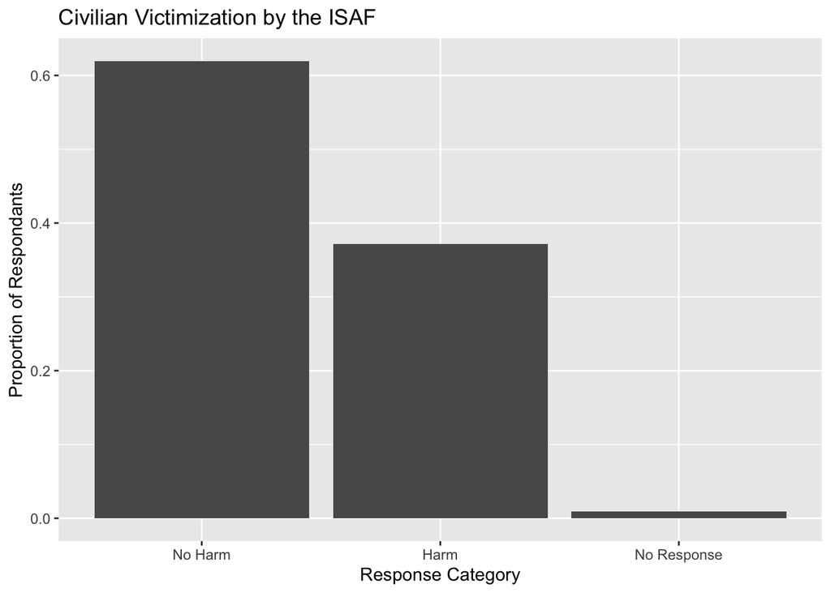

```r
#Bar plot for ISAF violence
afghan %>%
  ggplot(aes(x=as.factor(violent.exp.ISAF))) + # changes ISAF violence to a factor variable and will use it as x axis
  geom_bar(aes(y=..prop.., group=1)) + # specifies a proportion graph where all groups add to 1, geom_bar is used for bar plot
  scale_x_discrete(labels=c("No Harm", "Harm", "No Response")) + # adds labels to x axis categories
  xlab("Response Category") + # x axis title
  ylab("Proportion of Respondants") + # y axis title
  ggtitle("Civilian Victimization by the ISAF") # plot title
```

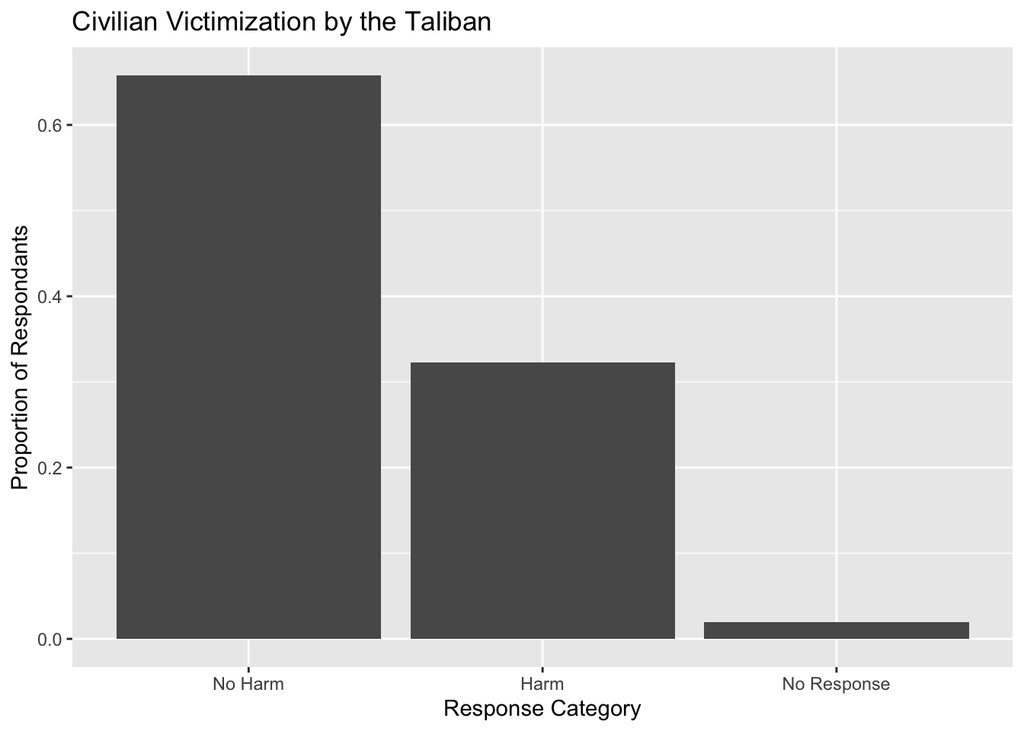

```r
#Bar plot for Taliban violence
afghan %>%
  ggplot(aes(x=as.factor(violent.exp.taliban))) + # changes Taliban violence to a factor variable and will use it as x axis
  geom_bar(aes(y=..prop.., group=1)) + # specifies a proportion graph where all groups add to 1, geom_bar is used for bar plot
  scale_x_discrete(labels=c("No Harm", "Harm", "No Response")) + # adds labels to x axis categories
  xlab("Response Category") + # x axis title
  ylab("Proportion of Respondants") + # y axis title
  ggtitle("Civilian Victimization by the Taliban") # plot title
```

```r
# see lab 3 vid for other way to do it if needed
```

Now, let’s combine the two bar plots so we can compare values more easily. First, reshape the dataset using `pivot_longer` to get a single column specifying whether the violence is caused by the ISAF or the Taliban. Then, use `ggplot` and the commands `fill`, `group`, and `position` to combine the barplots on the same graph.

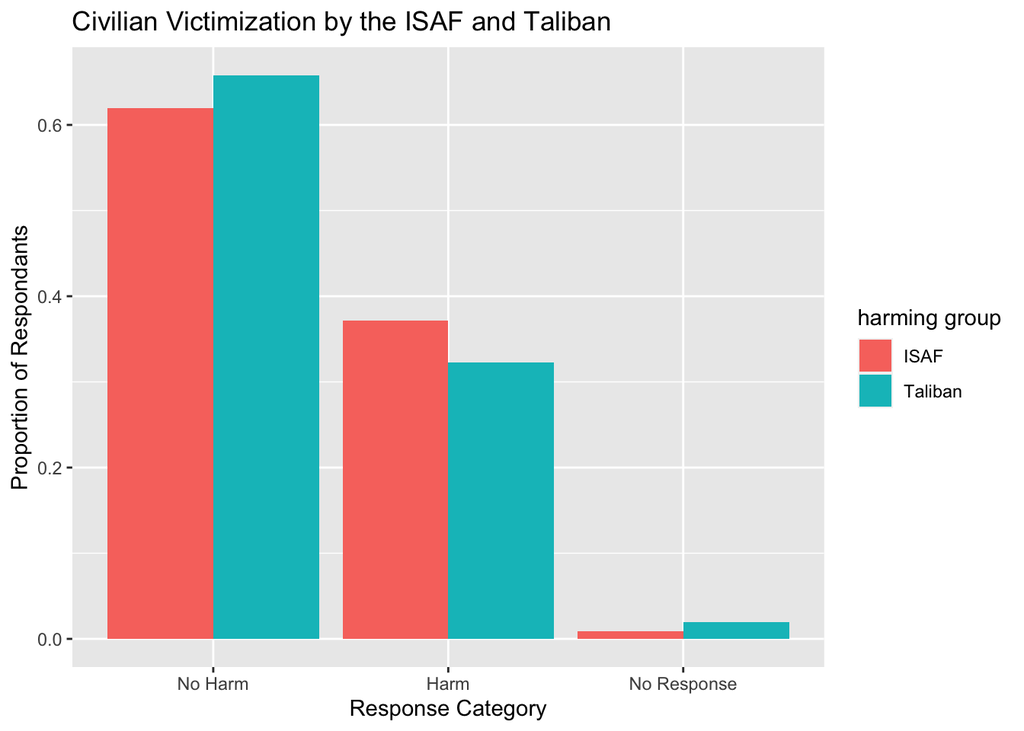

```r
#First, reshape the data
afghan_reshape= afghan %>%
  pivot_longer(violent.exp.ISAF:violent.exp.taliban, names_to = "harming_group", values_to="harm")
# names_to harming_group assigns ISAF and Taliban to be distinct bars in the plot
#values_to sends the values of each (no harm, harm, no response) to a new variable "harm" for later use

#Next, bar plot with both harm indicators together
afghan_reshape %>%
  ggplot(aes(x=as.factor(harm))) + # take harm variable from before and make it a factor variable
  geom_bar(aes(y=..prop..,
               fill=harming_group, # different color per group
               group=harming_group), # assign values to respective group
           position="dodge") + # don't stack bars, put them side to side
  scale_x_discrete(labels=c("No Harm", "Harm", "No Response")) + # adds labels to x axis categories
  scale_fill_discrete(name="harming group", labels=c("ISAF", "Taliban")) +
  xlab("Response Category") + # x axis title
  ylab("Proportion of Respondants") + # y axis title
  ggtitle("Civilian Victimization by the ISAF and Taliban") # plot title
```

In general, recall that we like to get a sense of central tendency (mean, median) and dispersion (IQR, standard deviation/variance) about numeric or continuous variables. Let’s start by obtaining the mean, median, and IQR for the variable “age” using the `select` and `summary`. (Hint: calculate the IQR yourself by subtracting the 3rd quartile from the 1st quartile).

```r
afghan %>%
  select(age) %>%
  summary()
```

```
##       age
##  Min.   :15.00
##  1st Qu.:22.00
##  Median :30.00
##  Mean   :32.39
##  3rd Qu.:40.00
##  Max.   :80.00
```

Now, let’s obtain the IQR (to check your work above), standard deviation, and variance for age using the `summarize()` command and filling in the parentheses with the desired descriptives (IQR, sd, var) for the variable `age`.

```r
afghan %>%
  summarise(IQR=IQR(age), sd=sd(age), var=var(age))
```

```
## # A tibble: 1 × 3
##     IQR    sd   var
##   <dbl> <dbl> <dbl>
## 1    18  12.3  151.
```

IQR is 18, sd = 12.29 and var = 151.03

Now, let’s visualize the distribution of age using a histogram using the `ggplot` function. Specify the data and the first “aesthetic” (`aes`) with variable of interest for the x-axis, `age`. Next, specify the type of plot, `geom_histogram`, with a second `aes` that indicates what will be on the y-axis (density), the binwidth (how wide each histogram bin will be), and the boundary (the bin position). Finally, you can make further specifications such as the spacing of the tick-marks on the x-axis (`scale_x_continuous`), and labels for the whole plot and your x and y axes (`labs()`).

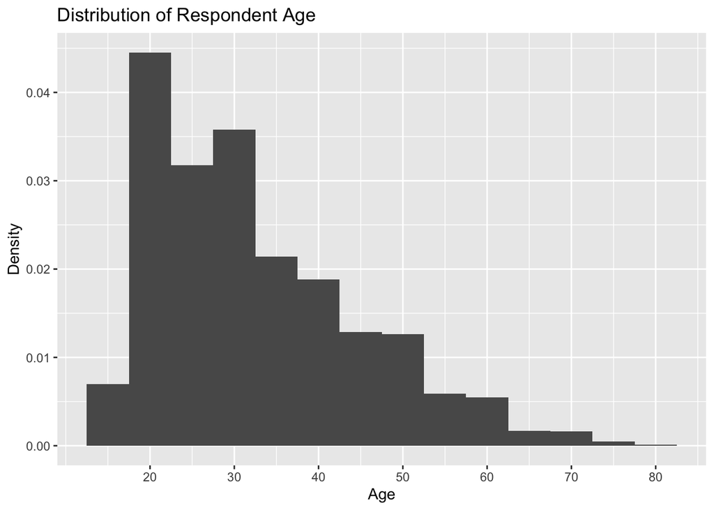

```r
afghan %>%
  ggplot(aes(x=age)) +
  geom_histogram(aes(y=..density..),
                 binwidth=5) +
  scale_x_continuous(breaks=seq(20,80,10)) + # sequence of 20-80 by 10
  labs(title="Distribution of Respondent Age", y="Density", x="Age")
```

Finally, let’s look at the distribution of age using a boxplot. use `ggplot` with the data `afghan`, `aes()` specifying age on the Y-axis, followed by the command `geom_boxplot`. Specify labels for x, y, and title using `labs()`.

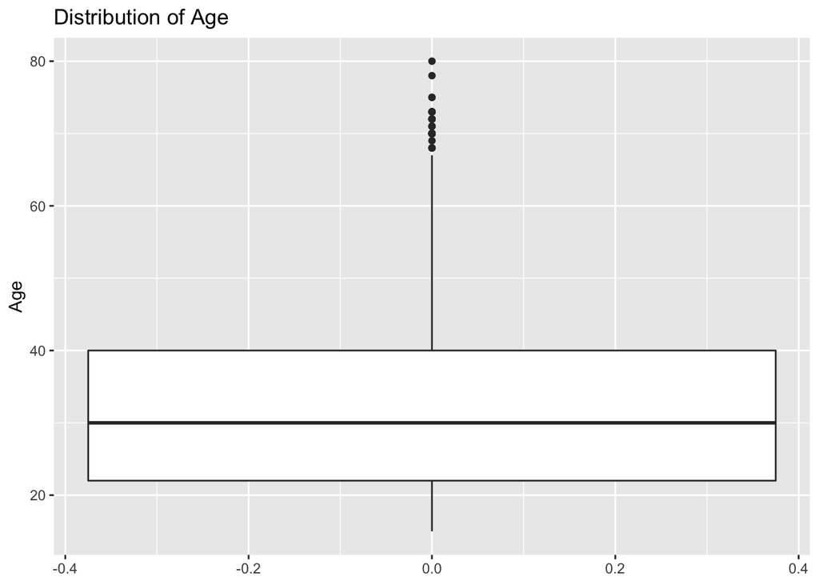

```r
afghan %>%
  ggplot(aes(y=age)) +
  geom_boxplot() +
  labs(y="Age", title="Distribution of Age")
```